# Assignment 13

Brian Roepkee

Dec 6, 2020

# Sentiment Analysis

Sentiment analysis of Twitter Data from Joe Biden’s and Donal Trump’s timelines.

## Load Libraries and Data

```r
# twitter library
library(rtweet)

# plotting and pipes
library(tidyverse)
library(ggplot2)
library(dplyr)
library(stringr)
library(tidyr)

# text mining library
library(tm)
library(tidytext)
library(wordcloud)
library(reshape2)
library(textstem)

# date/time library
library(lubridate)
```

```r
df <- read.csv("candidates.csv")
```

```r
# Convert the date field to a datetime
df$created_at <- as_datetime(df$created_at)

#Changed some fields to factors for easier manipulation later
df$user_id <- as.factor(df$user_id)
df$status_id <- as.factor(df$status_id)
df$screen_name <- as.factor(df$screen_name)

# Fix up the reply count field.  It should be a int and NAs set to 0
df$reply_count[is.na(df$reply_count)] <- 0
df$reply_count <- as.integer(df$reply_count)
```

```r
head(df)
```

|  | user_id | status_id | created_at | screen_name | text | source | display_text_width | reply_to_status_id | reply_to_user_id | reply_to_screen_name | is_quote | is_retweet | favorite_count | retweet_count | quote_count | reply_count | hashtags | symbols | urls_url | urls_t.co | urls_expanded_url | media_url | media_t.co | media_expanded_url | media_type | ext_media_url | ext_media_t.co | ext_media_expanded_url | ext_media_type | … |
| --- | --- | --- | --- | --- | --- | --- | --- | --- | --- | --- | --- | --- | --- | --- | --- | --- | --- | --- | --- | --- | --- | --- | --- | --- | --- | --- | --- | --- | --- | --- |
| 1 | x939091 | x1319032499456987136 | 2020-10-21 21:47:08 | JoeBiden | I couldn’t be more excited to have my friend @BarackObama hitting the campaign trail. Tune in for his first drive-in rally live from Philadelphia. https://t.co/NJyChqivOt | Periscope | 170 |  |  |  | FALSE | FALSE | 5501 | 981 | NA | 0 |  |  | pscp.tv/w/cl9SXDFvUEVM… | https://t.co/NJyChqivOt | https://www.pscp.tv/w/cl9SXDFvUEVMQkJiT2xyS2R8MXluSk9xeW1tYldLUtaExuJ65XDvOmFFLPeQvkYzHrZXqI0T_nyT6wU7Uh9H |  |  |  |  |  |  |  | NA | … |
| 2 | x939091 | x1319021893446492162 | 2020-10-21 21:05:00 | JoeBiden | It’s time we replace Secretary Betsy DeVos with an actual public school educator — one who values our public schools and is capable of guiding all of our schools through this pandemic.\n\nVote: https:… | Twitter Web App | 215 |  |  |  | TRUE | FALSE | 39009 | 6674 | NA | 0 |  |  | iwillvote.com twitter.com/thehill/status… | https://t.co/eoxT07d7QB https://t.co/CWf3H5BqOH | http://iwillvote.com https://twitter.com/thehill/status/1318730238088675333 |  |  |  |  |  |  |  | NA | … |
| 3 | x939091 | x1319010458414665728 | 2020-10-21 20:19:33 | JoeBiden | Tune in as @BarackObama sits down with community leaders in Philadelphia to talk about what’s at stake in this election. https://t.co/Xzmy0Cs3sw | Periscope | 144 |  |  |  | FALSE | FALSE | 13605 | 3006 | NA | 0 |  |  | pscp.tv/w/cl891TFvUEVM… | https://t.co/Xzmy0Cs3sw | https://www.pscp.tv/w/cl891TFvUEVMQkJiT2xyS2R8MXZBR1JydllFdlJHbMfQf60ATEyIyy-eSYY3yQeOS7tBLyS6EDK2hhweUYm8 |  |  |  |  |  |  |  | NA | … |
| 4 | x939091 | x1319006793931100162 | 2020-10-21 20:05:00 | JoeBiden | Hay muchos asuntos que son complicados, pero algunas cosas son visiblemente claras. Las familias deben permanecer unidas. https://t.co/rLC69J5rHI | TweetDeck | 145 |  |  |  | FALSE | FALSE | 5210 | 967 | NA | 0 |  |  | joebiden.com/es/2020/10/21/… | https://t.co/rLC69J5rHI | https://joebiden.com/es/2020/10/21/declaracion-del-vicepresidente-joe-biden-sobre-la-separacion-de-padres-e-hijos-en-la-frontera-durante-trump/ |  |  |  |  |  |  |  | NA | … |
| 5 | x939091 | x1319003018956886020 | 2020-10-21 19:50:00 | JoeBiden | There are many issues that are complicated, but some things are just black and white. Families belong together. https://t.co/TgIkhAMAtZ | TweetDeck | 135 |  |  |  | FALSE | FALSE | 11402 | 2252 | NA | 0 |  |  | joebiden.com/2020/10/21/tru… | https://t.co/TgIkhAMAtZ | https://joebiden.com/2020/10/21/trump-separation-of-children-and-parents-at-the-border-statement-by-vice-president-joe-biden/ |  |  |  |  |  |  |  | NA | … |
| 6 | x939091 | x1318998087176802304 | 2020-10-21 19:30:24 | JoeBiden | Cada día parece que descubrimos nuevos horrores cometidos por el presidente Trump y su administración. https://t.co/eefL58X7R8 | Twitter Web App | 102 |  |  |  | TRUE | FALSE | 20399 | 3767 | NA | 0 |  |  | twitter.com/NPR/status/131… | https://t.co/eefL58X7R8 | https://twitter.com/NPR/status/1318887313720692737 |  |  |  |  |  |  |  | NA | … |

```r
tail(df)
```

|  | user_id | status_id | created_at | screen_name | text | source | display_text_width | reply_to_status_id | reply_to_user_id | reply_to_screen_name | is_quote | is_retweet | favorite_count | retweet_count | quote_count | reply_count | hashtags | symbols | urls_url | urls_t.co | urls_expanded_url | media_url | media_t.co | media_expanded_url | media_type | ext_media_url | ext_media_t.co | ext_media_expanded_url | ext_media_type | … |
| --- | --- | --- | --- | --- | --- | --- | --- | --- | --- | --- | --- | --- | --- | --- | --- | --- | --- | --- | --- | --- | --- | --- | --- | --- | --- | --- | --- | --- | --- | --- |
| 6372 | x25073877 | x1290282508303716352 | 2020-08-03 13:44:56 | realDonaldTrump | So Crazy Nancy Pelosi said horrible things about Dr. Deborah Birx, going after her because she was too positive on the very good job we are doing on combatting the China Virus, including Vaccines &amp… | Twitter for iPhone | 288 |  |  |  | FALSE | FALSE | 98024 | 24863 | NA | 0 |  |  |  |  |  |  |  |  |  |  |  |  | NA | … |
| 6373 | x25073877 | x1290270589945430016 | 2020-08-03 12:57:35 | realDonaldTrump | Wow! Really bad TV Ratings for Morning Joe (@JoeNBC). @foxandfriends doing great, leading all others by far. @CNN not a factor!!! | Twitter for iPhone | 129 |  |  |  | FALSE | FALSE | 73966 | 15048 | NA | 0 |  |  |  |  |  |  |  |  |  |  |  |  | NA | … |
| 6374 | x25073877 | x1290261807282757632 | 2020-08-03 12:22:41 | realDonaldTrump | 96% Approval Rating in the Republican Party. 50% in new Rasmussen Poll (higher than Obama at this point in time). Thank you! | Twitter for iPhone | 124 |  |  |  | FALSE | FALSE | 151092 | 28252 | NA | 0 |  |  |  |  |  |  |  |  |  |  |  |  | NA | … |
| 6375 | x25073877 | x1290257055534551043 | 2020-08-03 12:03:48 | realDonaldTrump | Cases up because of BIG Testing! Much of our Country is doing very well. Open the Schools! | Twitter for iPhone | 90 |  |  |  | FALSE | FALSE | 173686 | 31696 | NA | 0 |  |  |  |  |  |  |  |  |  |  |  |  | NA | … |
| 6376 | x25073877 | x1290253369404092417 | 2020-08-03 11:49:09 | realDonaldTrump | FAKE NEWS IS THE ENEMY OF THE PEOPLE! | Twitter for iPhone | 37 |  |  |  | FALSE | FALSE | 416241 | 83536 | NA | 0 |  |  |  |  |  |  |  |  |  |  |  |  | NA | … |
| 6377 | x25073877 | x1290252674777133057 | 2020-08-03 11:46:24 | realDonaldTrump | With the exception of New York &amp; a few other locations, we’ve done MUCH better than most other Countries in dealing with the China Virus. Many of these countries are now having a major second wave… | Twitter for iPhone | 287 |  |  |  | FALSE | FALSE | 100233 | 22711 | NA | 0 |  |  |  |  |  |  |  |  |  |  |  |  | NA | … |

### Filter out Retweets

Validate the number of rows before and after removing retweets.

```r
nrow(df)
```

```
## [1] 6377
```

```r
df <- df %>%
  filter(is_retweet == FALSE)
head(df)
```

|  | user_id | status_id | created_at | screen_name | text | source | display_text_width | reply_to_status_id | reply_to_user_id | reply_to_screen_name | is_quote | is_retweet | favorite_count | retweet_count | quote_count | reply_count | hashtags | symbols | urls_url | urls_t.co | urls_expanded_url | media_url | media_t.co | media_expanded_url | media_type | ext_media_url | ext_media_t.co | ext_media_expanded_url | ext_media_type | … |
| --- | --- | --- | --- | --- | --- | --- | --- | --- | --- | --- | --- | --- | --- | --- | --- | --- | --- | --- | --- | --- | --- | --- | --- | --- | --- | --- | --- | --- | --- | --- |
| 1 | x939091 | x1319032499456987136 | 2020-10-21 21:47:08 | JoeBiden | I couldn’t be more excited to have my friend @BarackObama hitting the campaign trail. Tune in for his first drive-in rally live from Philadelphia. https://t.co/NJyChqivOt | Periscope | 170 |  |  |  | FALSE | FALSE | 5501 | 981 | NA | 0 |  |  | pscp.tv/w/cl9SXDFvUEVM… | https://t.co/NJyChqivOt | https://www.pscp.tv/w/cl9SXDFvUEVMQkJiT2xyS2R8MXluSk9xeW1tYldLUtaExuJ65XDvOmFFLPeQvkYzHrZXqI0T_nyT6wU7Uh9H |  |  |  |  |  |  |  | NA | … |
| 2 | x939091 | x1319021893446492162 | 2020-10-21 21:05:00 | JoeBiden | It’s time we replace Secretary Betsy DeVos with an actual public school educator — one who values our public schools and is capable of guiding all of our schools through this pandemic.\n\nVote: https:… | Twitter Web App | 215 |  |  |  | TRUE | FALSE | 39009 | 6674 | NA | 0 |  |  | iwillvote.com twitter.com/thehill/status… | https://t.co/eoxT07d7QB https://t.co/CWf3H5BqOH | http://iwillvote.com https://twitter.com/thehill/status/1318730238088675333 |  |  |  |  |  |  |  | NA | … |
| 3 | x939091 | x1319010458414665728 | 2020-10-21 20:19:33 | JoeBiden | Tune in as @BarackObama sits down with community leaders in Philadelphia to talk about what’s at stake in this election. https://t.co/Xzmy0Cs3sw | Periscope | 144 |  |  |  | FALSE | FALSE | 13605 | 3006 | NA | 0 |  |  | pscp.tv/w/cl891TFvUEVM… | https://t.co/Xzmy0Cs3sw | https://www.pscp.tv/w/cl891TFvUEVMQkJiT2xyS2R8MXZBR1JydllFdlJHbMfQf60ATEyIyy-eSYY3yQeOS7tBLyS6EDK2hhweUYm8 |  |  |  |  |  |  |  | NA | … |
| 4 | x939091 | x1319006793931100162 | 2020-10-21 20:05:00 | JoeBiden | Hay muchos asuntos que son complicados, pero algunas cosas son visiblemente claras. Las familias deben permanecer unidas. https://t.co/rLC69J5rHI | TweetDeck | 145 |  |  |  | FALSE | FALSE | 5210 | 967 | NA | 0 |  |  | joebiden.com/es/2020/10/21/… | https://t.co/rLC69J5rHI | https://joebiden.com/es/2020/10/21/declaracion-del-vicepresidente-joe-biden-sobre-la-separacion-de-padres-e-hijos-en-la-frontera-durante-trump/ |  |  |  |  |  |  |  | NA | … |
| 5 | x939091 | x1319003018956886020 | 2020-10-21 19:50:00 | JoeBiden | There are many issues that are complicated, but some things are just black and white. Families belong together. https://t.co/TgIkhAMAtZ | TweetDeck | 135 |  |  |  | FALSE | FALSE | 11402 | 2252 | NA | 0 |  |  | joebiden.com/2020/10/21/tru… | https://t.co/TgIkhAMAtZ | https://joebiden.com/2020/10/21/trump-separation-of-children-and-parents-at-the-border-statement-by-vice-president-joe-biden/ |  |  |  |  |  |  |  | NA | … |
| 6 | x939091 | x1318998087176802304 | 2020-10-21 19:30:24 | JoeBiden | Cada día parece que descubrimos nuevos horrores cometidos por el presidente Trump y su administración. https://t.co/eefL58X7R8 | Twitter Web App | 102 |  |  |  | TRUE | FALSE | 20399 | 3767 | NA | 0 |  |  | twitter.com/NPR/status/131… | https://t.co/eefL58X7R8 | https://twitter.com/NPR/status/1318887313720692737 |  |  |  |  |  |  |  | NA | … |

Show the total number of rows in this dataset.

```r
nrow(df)
```

```
## [1] 4765
```

### Add Doc_Id incrementing per Row

```r
df = df %>%
  mutate(doc_id = paste0("doc", row_number())) %>%
  select(doc_id, everything())
head(df)
```

|  | doc_id | user_id | status_id | created_at | screen_name | text | source | display_text_width | reply_to_status_id | reply_to_user_id | reply_to_screen_name | is_quote | is_retweet | favorite_count | retweet_count | quote_count | reply_count | hashtags | symbols | urls_url | urls_t.co | urls_expanded_url | media_url | media_t.co | media_expanded_url | media_type | ext_media_url | ext_media_t.co | ext_media_expanded_url | … |
| --- | --- | --- | --- | --- | --- | --- | --- | --- | --- | --- | --- | --- | --- | --- | --- | --- | --- | --- | --- | --- | --- | --- | --- | --- | --- | --- | --- | --- | --- | --- |
| 1 | doc1 | x939091 | x1319032499456987136 | 2020-10-21 21:47:08 | JoeBiden | I couldn’t be more excited to have my friend @BarackObama hitting the campaign trail. Tune in for his first drive-in rally live from Philadelphia. https://t.co/NJyChqivOt | Periscope | 170 |  |  |  | FALSE | FALSE | 5501 | 981 | NA | 0 |  |  | pscp.tv/w/cl9SXDFvUEVM… | https://t.co/NJyChqivOt | https://www.pscp.tv/w/cl9SXDFvUEVMQkJiT2xyS2R8MXluSk9xeW1tYldLUtaExuJ65XDvOmFFLPeQvkYzHrZXqI0T_nyT6wU7Uh9H |  |  |  |  |  |  |  | … |
| 2 | doc2 | x939091 | x1319021893446492162 | 2020-10-21 21:05:00 | JoeBiden | It’s time we replace Secretary Betsy DeVos with an actual public school educator — one who values our public schools and is capable of guiding all of our schools through this pandemic.\n\nVote: https:… | Twitter Web App | 215 |  |  |  | TRUE | FALSE | 39009 | 6674 | NA | 0 |  |  | iwillvote.com twitter.com/thehill/status… | https://t.co/eoxT07d7QB https://t.co/CWf3H5BqOH | http://iwillvote.com https://twitter.com/thehill/status/1318730238088675333 |  |  |  |  |  |  |  | … |
| 3 | doc3 | x939091 | x1319010458414665728 | 2020-10-21 20:19:33 | JoeBiden | Tune in as @BarackObama sits down with community leaders in Philadelphia to talk about what’s at stake in this election. https://t.co/Xzmy0Cs3sw | Periscope | 144 |  |  |  | FALSE | FALSE | 13605 | 3006 | NA | 0 |  |  | pscp.tv/w/cl891TFvUEVM… | https://t.co/Xzmy0Cs3sw | https://www.pscp.tv/w/cl891TFvUEVMQkJiT2xyS2R8MXZBR1JydllFdlJHbMfQf60ATEyIyy-eSYY3yQeOS7tBLyS6EDK2hhweUYm8 |  |  |  |  |  |  |  | … |
| 4 | doc4 | x939091 | x1319006793931100162 | 2020-10-21 20:05:00 | JoeBiden | Hay muchos asuntos que son complicados, pero algunas cosas son visiblemente claras. Las familias deben permanecer unidas. https://t.co/rLC69J5rHI | TweetDeck | 145 |  |  |  | FALSE | FALSE | 5210 | 967 | NA | 0 |  |  | joebiden.com/es/2020/10/21/… | https://t.co/rLC69J5rHI | https://joebiden.com/es/2020/10/21/declaracion-del-vicepresidente-joe-biden-sobre-la-separacion-de-padres-e-hijos-en-la-frontera-durante-trump/ |  |  |  |  |  |  |  | … |
| 5 | doc5 | x939091 | x1319003018956886020 | 2020-10-21 19:50:00 | JoeBiden | There are many issues that are complicated, but some things are just black and white. Families belong together. https://t.co/TgIkhAMAtZ | TweetDeck | 135 |  |  |  | FALSE | FALSE | 11402 | 2252 | NA | 0 |  |  | joebiden.com/2020/10/21/tru… | https://t.co/TgIkhAMAtZ | https://joebiden.com/2020/10/21/trump-separation-of-children-and-parents-at-the-border-statement-by-vice-president-joe-biden/ |  |  |  |  |  |  |  | … |
| 6 | doc6 | x939091 | x1318998087176802304 | 2020-10-21 19:30:24 | JoeBiden | Cada día parece que descubrimos nuevos horrores cometidos por el presidente Trump y su administración. https://t.co/eefL58X7R8 | Twitter Web App | 102 |  |  |  | TRUE | FALSE | 20399 | 3767 | NA | 0 |  |  | twitter.com/NPR/status/131… | https://t.co/eefL58X7R8 | https://twitter.com/NPR/status/1318887313720692737 |  |  |  |  |  |  |  | … |

### Add a Column for Text Length

```r
df$text_len <- str_count(df$text)
```

# EDA

Simplify the Data Frame to just the target fields we’ll be using throughout the analysis.

```r
df_select <- df %>%
  select(doc_id, user_id, status_id, screen_name, created_at, text, text_len)
```

## Tweet Length

```r
summary(df_select$text_len)
```

```
##    Min. 1st Qu.  Median    Mean 3rd Qu.    Max.
##     7.0    94.0   184.0   171.5   256.0   316.0
```

Tweets for the dataset range from `7` characters to `316` with a mean of `172`

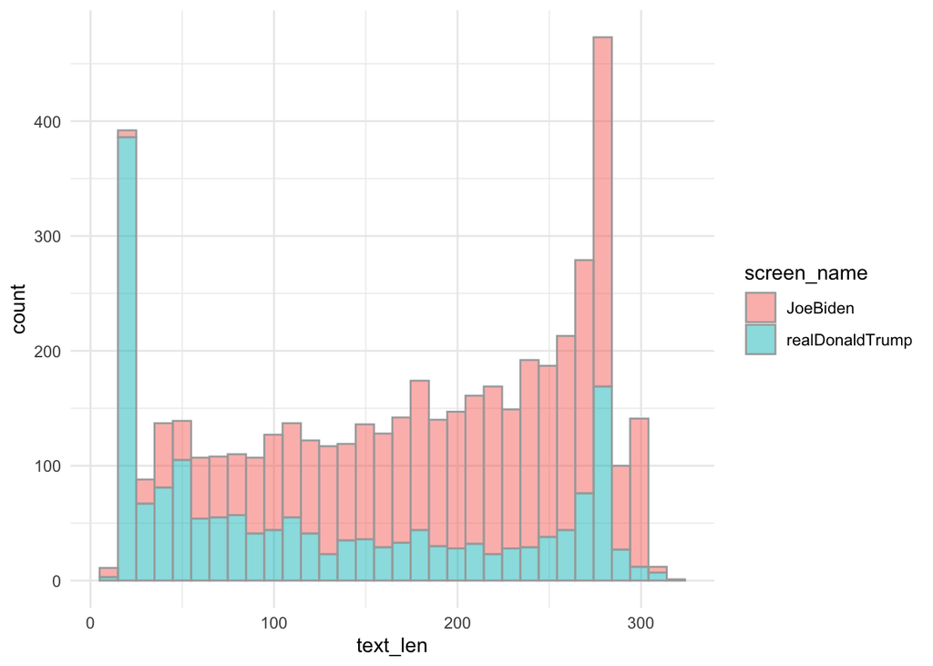

```r
df_select %>%
  ggplot(aes(x = text_len, fill = screen_name)) +
  geom_histogram(alpha = .5, color = "darkgray", bins = 32) +
  theme_minimal()
```

### Total Number of Tweets

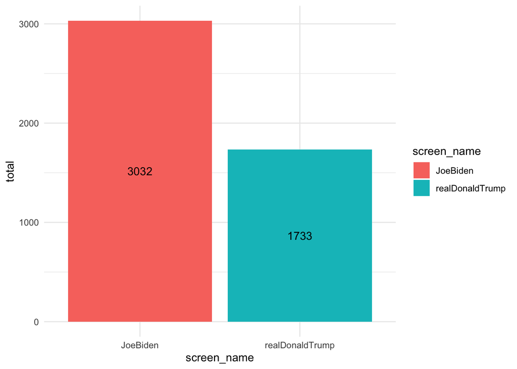

```r
df_select %>%
  group_by(screen_name) %>%
  summarise(total = n(), .groups = "keep") %>%
  ggplot(aes(x = screen_name, y = total, fill = screen_name)) +
  geom_col() +
  theme_minimal() +
  geom_text(aes(label = total), position = position_stack(vjust = 0.5))
```

After removing Retweets, Trumps total dropped to only `1,733`, while Biden’s fell much less to `3,032`. Trump Retweets more often than Biden.

### Tweets Over Time

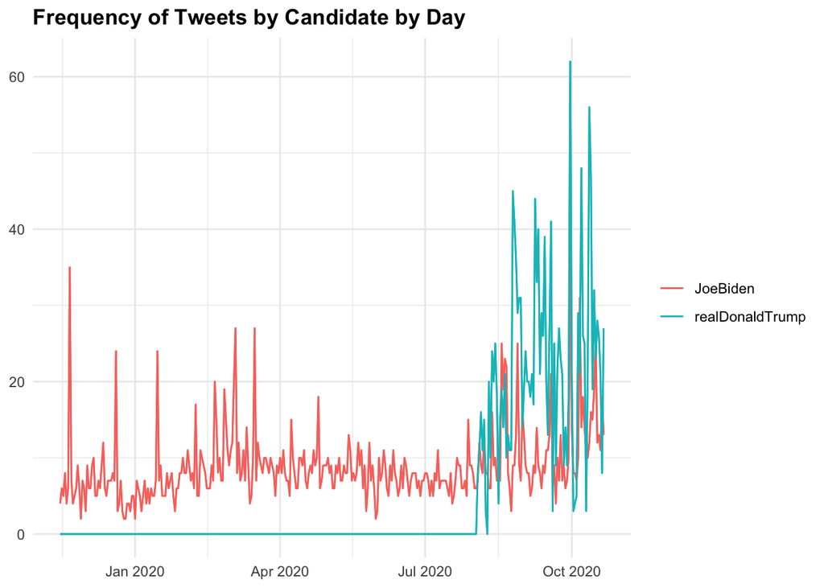

```r
df_select %>%
  dplyr::group_by(screen_name) %>%
  ts_plot("days", trim = 0L) +
  ggplot2::geom_line() +
  ggplot2::theme_minimal() +
  ggplot2::theme(
    legend.title = ggplot2::element_blank(),
    legend.position = "right",
    plot.title = ggplot2::element_text(face = "bold")) +
  ggplot2::labs(
    x = NULL, y = NULL,
    title = "Frequency of Tweets by Candidate by Day"
  )
```

Based on the way this dataset was collected (last 3200 tweets per candidate), the data from Trump is compressed to dates starting around August. This is due to the fact that he tweets more regularly than Biden, hitting the 3,200 tweet limit sooner.

# Clean and Prepare the Text for Analysis

Get rid of various useless text like URLS and shortened URLs. These appear frequently in the text and skew results.

### Clean Twitter specific items

https://stackoverflow.com/questions/31348453/how-do-i-clean-twitter-data-in-r

```r
df_select$text = gsub("[ \t]{2,}", " ", df_select$text)
df_select$text = gsub("(RT|via)((?:\\b\\W*@\\w+)+)", "", df_select$text)
df_select$text = gsub("@\\w+", " ", df_select$text)
df_select$text = gsub("[[:digit:]]", " ", df_select$text)
df_select$text = gsub("http\\w+", " ", df_select$text)
df_select$text = gsub("^\\s+|\\s+$", " ", df_select$text)
```

### Remove Whitespace and Lemmatize

```r
df_select$text = stripWhitespace(df_select$text)
df_select$text = lemmatize_strings(df_select$text)
```

### Unnest_Tokens()

Create a new column with each word on it’s own row.

```r
tidy_df <- df_select %>%
  unnest_tokens(word, text)
```

### Stop Word Removal

remove stop words and custom stop words from the results.

Note: Removing Trump because it’s a proper name but also an verb which was marked as positive and appeared in the top results for both candidates.

```r
custom_stop_words <- bind_rows(tibble(word = c("trump"), lexicon = c("custom")), stop_words)

tidy_df <- tidy_df %>%
  anti_join(custom_stop_words, by = "word")
```

### Validate the New number of Rows

Dramatically larger now that each word from text is in it’s own row.

```r
nrow(tidy_df)
```

```
## [1] 54903
```

After unnesting the words, each word of the tweet is on a separate line. The following is an example.

```r
tidy_df %>%
  filter(status_id == "x1319032499456987136") %>%
  head(n=10)
```

|  | doc_id | user_id | status_id | screen_name | created_at | text_len | word |
| --- | --- | --- | --- | --- | --- | --- | --- |
| 1.1 | doc1 | x939091 | x1319032499456987136 | JoeBiden | 2020-10-21 21:47:08 | 170 | couldn |
| 1.5 | doc1 | x939091 | x1319032499456987136 | JoeBiden | 2020-10-21 21:47:08 | 170 | excite |
| 1.9 | doc1 | x939091 | x1319032499456987136 | JoeBiden | 2020-10-21 21:47:08 | 170 | friend |
| 1.10 | doc1 | x939091 | x1319032499456987136 | JoeBiden | 2020-10-21 21:47:08 | 170 | hit |
| 1.12 | doc1 | x939091 | x1319032499456987136 | JoeBiden | 2020-10-21 21:47:08 | 170 | campaign |
| 1.13 | doc1 | x939091 | x1319032499456987136 | JoeBiden | 2020-10-21 21:47:08 | 170 | trail |
| 1.14 | doc1 | x939091 | x1319032499456987136 | JoeBiden | 2020-10-21 21:47:08 | 170 | tune |
| 1.19 | doc1 | x939091 | x1319032499456987136 | JoeBiden | 2020-10-21 21:47:08 | 170 | drive |
| 1.21 | doc1 | x939091 | x1319032499456987136 | JoeBiden | 2020-10-21 21:47:08 | 170 | rally |
| 1.22 | doc1 | x939091 | x1319032499456987136 | JoeBiden | 2020-10-21 21:47:08 | 170 | live |

# Sentiment Analysis

## Bing Sentiment Lexicon

Using the Bing Lexicon from Bing Liu and collaborators, adds the column “Sentiment” and mark each word as positive or negative.

https://www.cs.uic.edu/~liub/FBS/sentiment-analysis.html

```r
bing_df <- tidy_df %>%
  inner_join(get_sentiments("bing"), by = "word")
```

```r
bing_df %>%
  group_by(screen_name, sentiment) %>%
  summarise(count = n(), .groups = "keep")
```

| screen_name | sentiment | count |
| --- | --- | --- |
| JoeBiden | negative | 2961 |
| JoeBiden | positive | 3131 |
| realDonaldTrump | negative | 1470 |
| realDonaldTrump | positive | 1230 |

### AFINN scoring Lexicon

AFINN from Finn Årup Nielsen, adds the `value` column, with a numeric representation of how positive, or negative the word is. The AFINN lexicon measures sentiment with a numeric score between -5 and 5

http://www2.imm.dtu.dk/pubdb/pubs/6010-full.html

```r
afinn_df <- tidy_df %>%
  inner_join(get_sentiments("afinn"), by = "word")

head(afinn_df)
```

|  | doc_id | user_id | status_id | screen_name | created_at | text_len | word | value |
| --- | --- | --- | --- | --- | --- | --- | --- | --- |
| 1 | doc1 | x939091 | x1319032499456987136 | JoeBiden | 2020-10-21 21:47:08 | 170 | excite | 3 |
| 2 | doc2 | x939091 | x1319021893446492162 | JoeBiden | 2020-10-21 21:05:00 | 239 | capable | 1 |
| 3 | doc8 | x939091 | x1318960740657672193 | JoeBiden | 2020-10-21 17:02:00 | 281 | love | 3 |
| 4 | doc8 | x939091 | x1318960740657672193 | JoeBiden | 2020-10-21 17:02:00 | 281 | fight | -1 |
| 5 | doc9 | x939091 | x1318937589097717760 | JoeBiden | 2020-10-21 15:30:00 | 74 | justice | 2 |
| 6 | doc12 | x939091 | x1318753877076881408 | JoeBiden | 2020-10-21 03:20:00 | 126 | love | 3 |

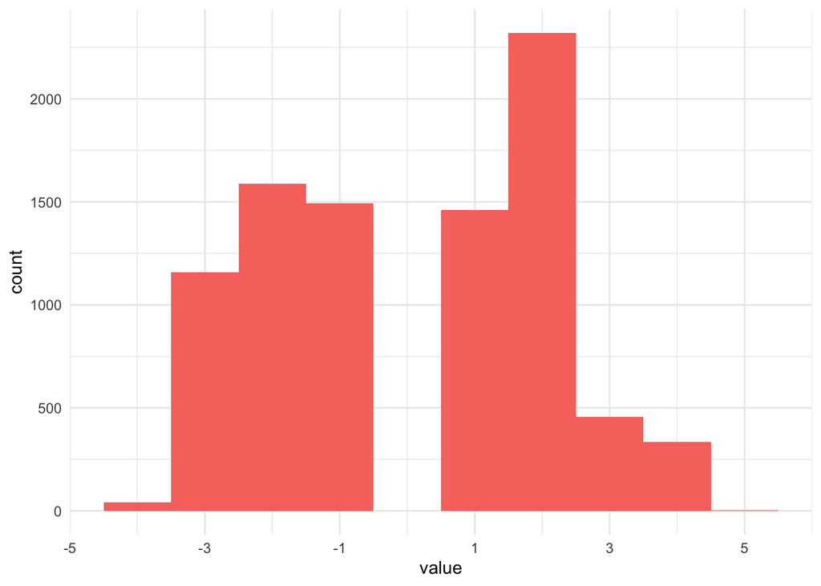

```r
afinn_df %>%
  ggplot(aes(x = value, fill = "#F8766D")) +
  geom_histogram(bins = 10, show.legend = FALSE) +
  scale_x_continuous(breaks = c(-5, -3, -1, 1, 3, 5)) +
  theme_minimal()
```

For the dataset overall, there is a slight left-skew showing there is a greater concentration of words with positive values. There are very few in the high and low values (`-4`,`-5`, `+5`).

*Note: `0` is not a valid value in this scoring system, therefore the bin is empty*

### NRC Sentiment Lexicon

NRC from Saif Mohammad and Peter Turney. The NRC Emotion Lexicon is a list of English words and their associations with eight basic emotions as well as positive and negative sentiment.

One thing to note, single words can have multiple emotions

```r
nrc_df <- tidy_df %>%
  inner_join(get_sentiments("nrc"), by = "word")
```

Total counts for all 8 emotions and 2 sentiments.

```r
nrc_df %>%
  group_by(sentiment) %>%
  summarise(total = n(), .groups = "keep") %>%
  arrange(desc(total))
```

| sentiment | total |
| --- | --- |
| positive | 9760 |
| trust | 7086 |
| negative | 6041 |
| anticipation | 4473 |
| fear | 3641 |
| anger | 3390 |
| joy | 3258 |
| sadness | 2896 |
| surprise | 1821 |
| disgust | 1545 |

## Inspect Top Words Per Candidate

Using various methods, inspect what words are most frequently used, per candidate, proportions of negative and positive words, and trend over time.

### Top Word Counts (BING)

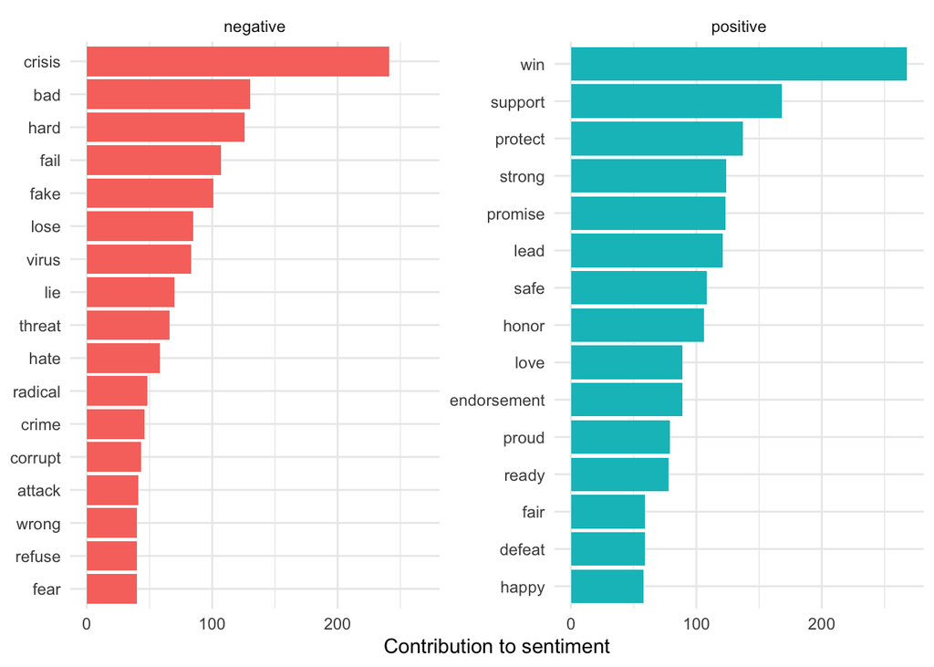

```r
bing_df %>%
  count(word, sort = TRUE, sentiment) %>%

  group_by(sentiment) %>%
  top_n(15) %>%
  ungroup() %>%
  mutate(word = reorder(word, n)) %>%
  ggplot(aes(n, word, fill = sentiment)) +
  geom_col(show.legend = FALSE) +
  facet_wrap(~sentiment, scales = "free_y") +
  theme_minimal() +
  labs(x = "Contribution to sentiment",
       y = NULL)
```

When looking at data as a whole, we can see the top negative word is `crisis` and positive is `win`. Next, we’ll split these out by candidate.

### Top Word Count Per Candidate (BING)

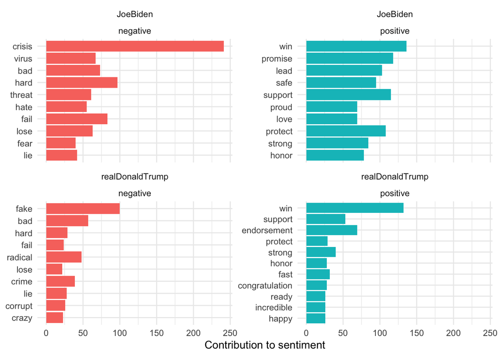

```r
bing_df %>%
  count(word, sort = TRUE, screen_name, sentiment) %>%

  group_by(screen_name, sentiment) %>%
  top_n(10) %>%
  ungroup() %>%
  mutate(word = reorder(word, n)) %>%
  ggplot(aes(n, word, fill = sentiment)) +
  geom_col(show.legend = FALSE) +
  facet_wrap(vars(screen_name, sentiment), scales = "free_y") +
  theme_minimal() +
  labs(x = "Contribution to sentiment",y = NULL)
```

**Positive**: Both candidates show `win` as the top word and `support`, `strong`, `honor`, and `protect` in their top 10. Biden uses `promise`, `safe`, `protect`, and `love`. Trump uses `endorsement`, `fast`, `congratulations`, `incredible` and `happy`.

### Overall Top Words (BING)

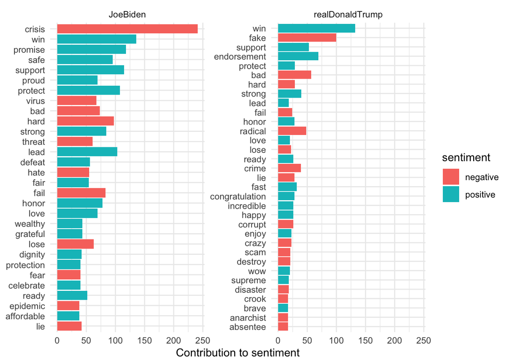

```r
bing_df %>%
  count(word, sort = TRUE, sentiment, screen_name) %>%

  group_by(screen_name) %>%
  top_n(30) %>%
  ungroup() %>%
  mutate(word = reorder(word, n)) %>%
  ggplot(aes(n, word, fill = sentiment)) +
  geom_col(show.legend = TRUE) +
  facet_wrap(~screen_name, scales = "free_y") +
  theme_minimal() +
  labs(x = "Contribution to sentiment", y = NULL)
```

Looking at the mix of top `30` words and whether they’re positive or negative. Both candidates are about the same. There is a mix of positive and negative words throughout. Biden tends to have a little more positive words clustered at the top where Trump is more mixed.

### Top Words Sorted by AFINN Score

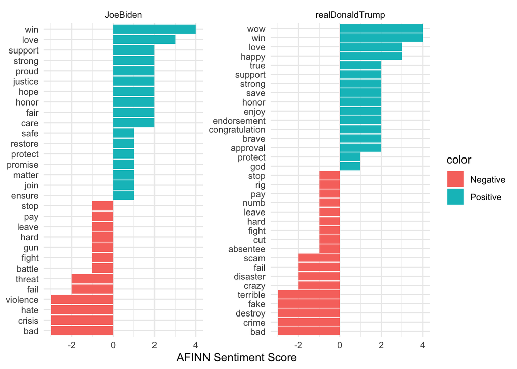

```r
afinn_df$color <- ifelse(afinn_df$value < 0, "Negative","Positive")

afinn_df %>%
  count(word, sort = TRUE, screen_name, value, color) %>%
  group_by(screen_name) %>%
  top_n(30) %>%
  ungroup() %>%
  mutate(word = reorder(word, value)) %>%

  ggplot(aes(value, word, fill = color)) +
  geom_col(show.legend = TRUE) +
  facet_wrap(~screen_name, scales = "free_y") +
  theme_minimal() +
  labs(x = "AFINN Sentiment Score", y = NULL)
```

Top 30 words, sorted by their AFINN score, a scale of `-5` to`5`. Biden used slightly more positive words in his top `30`. Both seem generally balanced when sorted this way.

### Overall Sentiment per Candidate (AFINN)

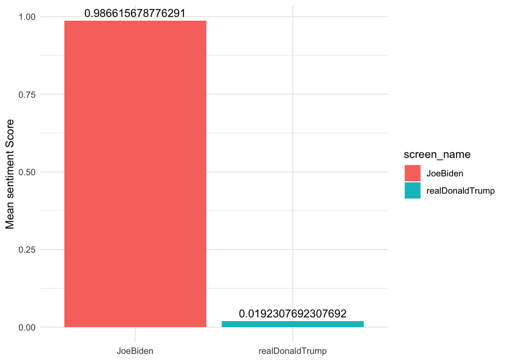

```r
afinn_df %>%
  count(word, sort = TRUE, screen_name, value) %>%
  group_by(screen_name) %>%
  summarize(avg = mean(value * n), .groups = "keep") %>%

  mutate(screen_name = reorder(screen_name, avg)) %>%
  ggplot(aes(avg, screen_name, fill = screen_name, label = avg)) +
  geom_col() +
  labs(x = "Mean sentiment Score", y = NULL) +
  theme_minimal() +
  geom_text(position = position_dodge(width = 0.9), vjust = -0.5) +
  coord_flip()
```

The MEAN sentiment score is a mean calculation using the AFINN lexicon. As a remember this scale can go from `-5` to `+5`. The calculation takes into account the AFINN sentiment score multiplied by the number of times that work occurs and then calculates the MEAN. We see that Biden’s is approximately `+1` while Trumps is just over `0`.

### Sentiment of Tweets over Time (AFINN)

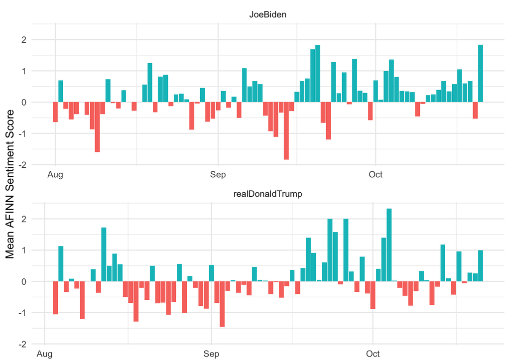

```r
plot_df2 <- afinn_df %>%
  filter(created_at > "2020-08-01") %>%
  mutate(mon = floor_date(created_at, "day")) %>%
  group_by(screen_name, mon) %>%
  summarize(value = mean(value), .groups = 'keep')

plot_df2$color <- ifelse(plot_df2$value < 0, "negative","positive")

ggplot(plot_df2, aes(mon, value, fill = color)) +
  geom_col(show.legend = FALSE) +
  facet_wrap(~screen_name, ncol = 1, scales = "free_x") +
  labs(x = NULL, y = "Mean AFINN Sentiment Score") +
  theme_minimal()
```

Since August, showing the frequency of sentiment for each candidate. Using the mean sentiment score we can see how each candidate tweeted on a daily basis. Trumps earlier timeline tended to be more negative, while both candidates were more positive starting mid September.

### Top Emotions Per Candidate

```r
nrc_biden <- nrc_df %>%
  filter(screen_name == "JoeBiden") %>%
  mutate(sum = n()) %>%
  group_by(sentiment, word, sum) %>%
  summarise(avg = mean(n() / sum), .groups = "keep") %>%
  group_by(sentiment) %>%
  summarise(mean = sum(avg), .groups = "keep") %>%
  arrange(desc(mean))

nrc_trump <- nrc_df %>%
  filter(screen_name == "realDonaldTrump") %>%
  mutate(sum = n()) %>%
  group_by(sentiment, word, sum) %>%
  summarise(avg = mean(n() / sum), .groups = "keep") %>%
  group_by(sentiment) %>%
  summarise(mean = sum(avg), .groups = "keep") %>%
  arrange(desc(mean))

# Put them back into a single dataframe for graphics
nrc_biden$screen_name <- "JoeBiden"
nrc_trump$screen_name <- "realDonaldTrump"
nrc_final <- rbind(nrc_trump, nrc_biden)
```

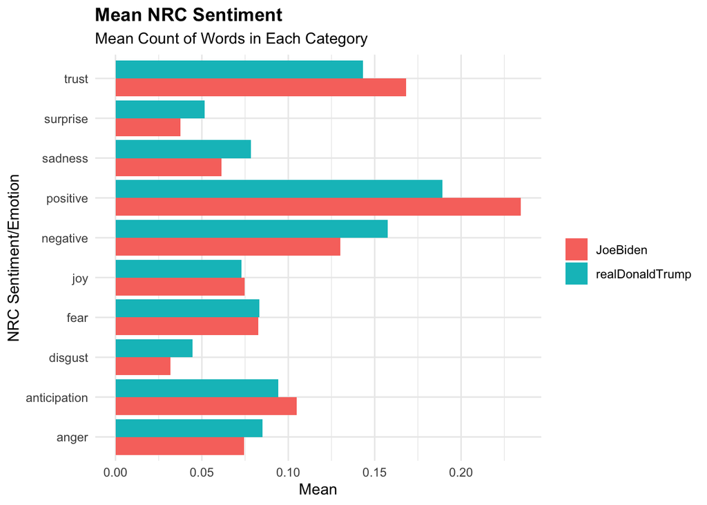

```r
ggplot(nrc_final, aes(x = mean, y = sentiment, fill = screen_name)) +
  geom_col(position = "dodge") +
  theme_minimal() +
  labs(
    x = "Mean",
    y = "NRC Sentiment/Emotion",
    title = "Mean NRC Sentiment",
    subtitle = "Mean Count of Words in Each Category"
  ) +
  theme(
    legend.title = element_blank(),
    legend.position = "right",
    plot.title = element_text(face = "bold"))
```

- **Biden** has a greater mean across: `trust`, `positive`, `joy`, and `anticipation`.
- **Trump** has a greater mean across: `surprise`, `sadness`, `negative`, `fear`, `disgust`, and `anger`.

### Find most positive and negative individual messages by user (AFINN)

#### Most Positive Biden Messages

```r
afinn_df %>%
  filter(screen_name == "JoeBiden") %>%
  group_by(doc_id) %>%
  summarize(total_value = sum(value), word_count = n(), .groups = "keep") %>%
  arrange(desc(total_value)) %>%
  head()
```

| doc_id | total_value | word_count |
| --- | --- | --- |
| doc2737 | 17 | 6 |
| doc2894 | 17 | 9 |
| doc2038 | 14 | 7 |
| doc2554 | 14 | 5 |
| doc2323 | 13 | 6 |
| doc290 | 13 | 6 |

```r
df %>%
  filter(doc_id == "doc2737" | doc_id == "doc2894") %>%
  select(text)
```

| text |
| --- |
| May your time with loved ones be full of peace, laughter, and joy. Merry Christmas and Happy Holidays. With love, from my family to yours. https://t.co/L7mwR4nBKd |
| Every worker deserves fair wages, good benefits, and protections from sexual harassment. I’m proud to stand in solidarity with @hgsuuaw. I urge the university to negotiate in good faith to secure a fa… |

#### Most Negative Biden Messages

```r
afinn_df %>%
  filter(screen_name == "JoeBiden") %>%
  group_by(doc_id) %>%
  summarize(total_value = sum(value), word_count = n(), .groups = "keep") %>%
  arrange(total_value) %>%
  head()
```

| doc_id | total_value | word_count |
| --- | --- | --- |
| doc2504 | -15 | 6 |
| doc623 | -15 | 8 |
| doc145 | -14 | 7 |
| doc323 | -14 | 7 |
| doc1811 | -13 | 5 |
| doc2558 | -13 | 6 |

```r
df %>%
  filter(doc_id == "doc2504" | doc_id == "doc623") %>%
  select(text)
```

| text |
| --- |
| The deadly violence we saw overnight in Portland is unacceptable. Shooting in the streets of a great American city is unacceptable.\n\nI condemn violence of every kind by anyone, whether on the left o… |
| We are in the midst of a crisis with the coronavirus. We need to lead the way with science — not Donald Trump’s record of hysteria, xenophobia, and fear-mongering. He is the worst possible person to l… |

#### Most Positive Trump Messages

```r
afinn_df %>%
  filter(screen_name == "realDonaldTrump") %>%
  group_by(doc_id) %>%
  summarize(total_value = sum(value), word_count = n(), .groups = "keep") %>%
  arrange(desc(total_value)) %>%
  head()
```

| doc_id | total_value | word_count |
| --- | --- | --- |
| doc3173 | 27 | 7 |
| doc3708 | 25 | 7 |
| doc3213 | 24 | 6 |
| doc3804 | 19 | 9 |
| doc3925 | 19 | 9 |
| doc4104 | 16 | 5 |

```r
df %>%
  filter(doc_id == "doc3173" | doc_id == "doc3708") %>%
  select(text)
```

| text |
| --- |
| It was great to be back in North Carolina with thousands of loyal, hardworking American Patriots! This election is a simple choice: If Biden Wins, China Wins. When WE Win, YOU WIN, North Carolina WINS… |
| I was honored to be back in the Commonwealth of Pennsylvania with thousands of loyal, hardworking American Patriots. This election is a choice between Pennsylvania &amp; China. If Biden wins, China wi… |

#### Most Negative Trump Messages

```r
afinn_df %>%
  filter(screen_name == "realDonaldTrump") %>%
  group_by(doc_id) %>%
  summarize(total_value = sum(value), word_count = n(), .groups = "keep") %>%
  arrange(total_value) %>%
  head()
```

| doc_id | total_value | word_count |
| --- | --- | --- |
| doc3190 | -16 | 6 |
| doc4219 | -16 | 6 |
| doc4428 | -16 | 8 |
| doc4173 | -15 | 8 |
| doc4514 | -15 | 8 |
| doc3863 | -14 | 7 |

```r
df %>%
  filter(doc_id == "doc3190" | doc_id == "doc4219") %>%
  select(text)
```

| text |
| --- |
| I’ve gone through years of a Fake, Illegal, and Totally Discredited Witch-Hunt, and now it’s revealed that it was a Hoax by the “other side”, which must pay a price for what they did. Think of where w… |
| Will Fredo be fired by Fake News @CNN? He speaks with great disrespect about women, and it will only get worse. Fredo’s Ratings are bad, so this is the time. Always terrible to speak to sleazebags, es… |

# Word Clouds

Visualize the most prominent words overall, and for each candidate.

## Overall Word Cloud

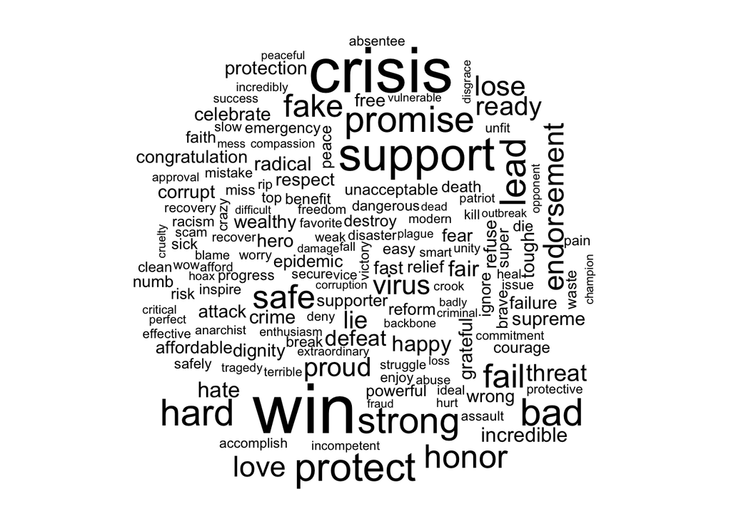

```r
bing_df %>%
  count(word) %>%
  with(wordcloud(word, n, max.words = 150))
```

### Biden

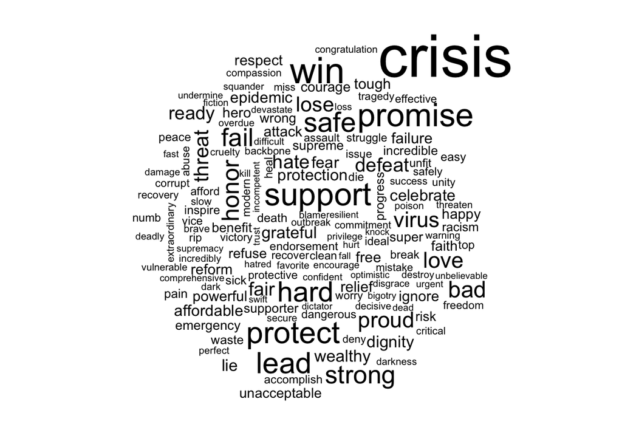

```r
bing_df %>%
  filter(screen_name == "JoeBiden") %>%
  count(word) %>%
  with(wordcloud(word, n, max.words = 150))
```

### Trump

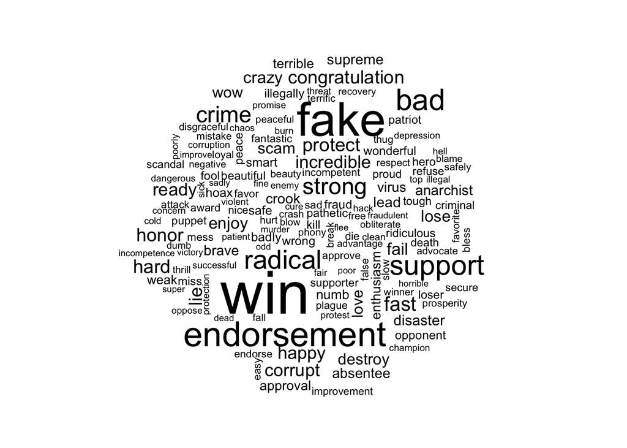

```r
bing_df %>%
  filter(screen_name == "realDonaldTrump") %>%
  count(word) %>%
  with(wordcloud(word, n, max.words = 150))
```

## By Sentiment

Word cloud of the top 200 words grouped by sentiment, positive or negative.

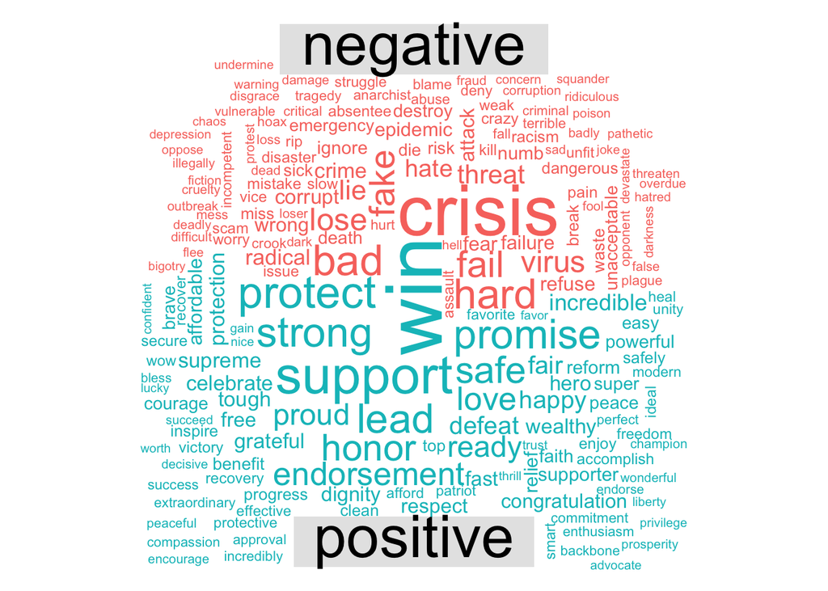

```r
bing_df %>%
  count(word, sentiment, sort = TRUE) %>%
  acast(word ~ sentiment, value.var = "n", fill = 0) %>%
  comparison.cloud(colors = c("#F8766D", "#00BFC4"), max.words = 200)
```

# Checking for Top-Negation Word Pairs

The method used here doesn’t take into account negation of words like no, and never preceding words. We can quckly check the top word pairs to see how they occur in our text.

```r
bigrams <- df_select %>%
  unnest_tokens(bigram, text, token = "ngrams", n = 2)
```

```r
bigram_counts <- bigrams %>%
  count(bigram, sort = TRUE) %>%
  separate(bigram, c("word1", "word2"), sep = " ")

head(bigram_counts, n=10)
```

|  | word1 | word2 | n |
| --- | --- | --- | --- |
| 1 | t | co | 3471 |
| 2 | donald | trump | 588 |
| 3 | of | the | 452 |
| 4 | be | a | 437 |
| 5 | in | the | 395 |
| 6 | i | be | 349 |
| 7 | we | have | 339 |
| 8 | we | need | 317 |
| 9 | on | the | 285 |
| 10 | to | the | 284 |

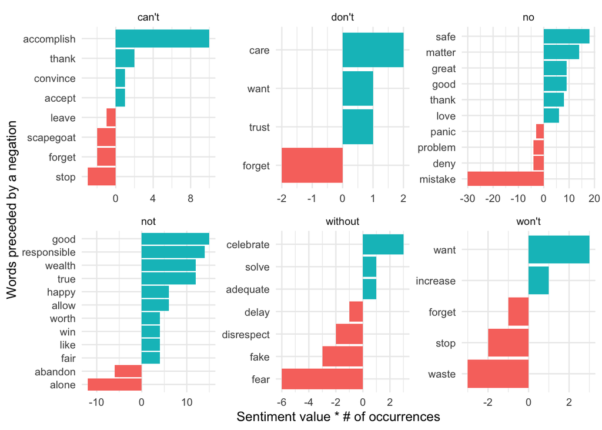

```r
negate_words <- c("not", "without", "no", "can't", "don't", "won't")


bigram_counts %>%
  filter(word1 %in% negate_words) %>%
  count(word1, word2, wt = n, sort = TRUE) %>%
  inner_join(get_sentiments("afinn"), by = c(word2 = "word")) %>%
  mutate(contribution = value * n) %>%
  group_by(word1) %>%
  slice_max(abs(contribution), n = 10) %>%
  ungroup() %>%
  mutate(word2 = reorder_within(word2, contribution, word1)) %>%

  ggplot(aes(contribution, word2, fill = contribution > 0)) +
  geom_col(show.legend = FALSE) +
  facet_wrap(~word1, scales = "free", nrow = 2) +
  scale_y_reordered() +
  theme_minimal() +
  labs(x = "Sentiment value * # of occurrences",
       y = "Words preceded by a negation")
```

Both `not` and `no` have a high proportion of positive sentiment scored words associated with them. Further techniques could take these into account such as removing them via the custom stop words or potentially other methods. However, for this exercise, they will remain in the model.